# Home Credit Default Risk Exploratory Data Analysis

Understanding the application data before modeling

Published

September 21, 2026

## Executive summary

For this project, I explored the application data to understand what it contains and what needs to be fixed before modeling. The training file has 307,511 applications and 121 possible predictor columns. Only 8.07% of the applicants had the payment difficulties identified by `TARGET`. The external scores and applicant age have the clearest individual relationships with the target, but neither one would be enough to make an approval decision by itself.

The dataset also has several problems that will affect preparation and modeling. Many fields are missing, 18% of the employment-duration values use an impossible code, a few category labels are invalid, and some monetary values are unusually large. The mix of loan types is also different between the training and test data.

Based on these results, missing values and unusual codes will need to be handled carefully. Any preparation steps must be learned from the training folds so that information from validation data does not leak into the model. The model should be evaluated with ROC AUC, precision-recall results, calibration, and approval-threshold comparisons. The group differences shown in this notebook are relationships in the data. They do not prove that any characteristic causes payment difficulties, and they should not be used alone to approve or decline an applicant.

## Business problem and EDA questions

Home Credit provides loans to customers that traditional banks may turn away, including customers with little or no credit history. This creates two risks for the company. Home Credit could approve an applicant who later has payment difficulties, or it could decline an applicant who would have repaid. The purpose of this project is to use the available historical data to help underwriters estimate the risk of each application. The model would support the approval process, but it would not replace company policy, affordability checks, or underwriter review.

In the supplied data, `TARGET = 1` means the customer had a late payment that met the dataset’s definition of payment difficulty during the first installments. The exact number of late days and installments is not provided. ROC AUC can show how well a model ranks higher-risk and lower-risk applicants, but it does not decide which applications should be approved. A useful final evaluation will also need to compare approval volume, payment-difficulty rates, calibration, and results for important applicant groups.

I used the business problem, the assignment requirements, and the structure of the data to develop five EDA questions:

1. What is the observation grain, and can the training and test files be combined or joined safely?
2. How imbalanced is the target, and what does that imply for evaluation?
3. Which values are missing, invalid, sentinel-coded, or unusually extreme?
4. Which applicant and loan characteristics have the strongest descriptive relationship with payment difficulty?
5. Are the training and test applications similar enough for a model trained on one to work well on the other?

## Setup and data loading

For this stage of the project, I only used `application_train.csv` and `application_test.csv`. The assignment does not require the supplementary tables yet, so I left them out and kept the analysis at the application level.

```r
# Load the packages used for data work, plots, and tables.
library(data.table)
library(ggplot2)
library(scales)
library(knitr)

# Set file paths so the notebook works from the project or notebook folder.
project_root <- if (file.exists("data/raw/application_train.csv")) "." else ".."
train_path <- file.path(project_root, "data", "raw", "application_train.csv")
test_path  <- file.path(project_root, "data", "raw", "application_test.csv")
dictionary_path <- file.path(project_root, "docs", "HomeCredit_columns_description.csv")

# Read blank fields as missing values and hide the loading progress bar.
train <- fread(train_path, na.strings = c("", "NA"), showProgress = FALSE)
test  <- fread(test_path,  na.strings = c("", "NA"), showProgress = FALSE)
dictionary <- fread(dictionary_path, encoding = "Latin-1", showProgress = FALSE)

# Use the same plot style and colors throughout the notebook.
theme_set(
  theme_minimal(base_size = 12) +
    theme(
      plot.title.position = "plot",
      plot.title = element_text(face = "bold", size = 14),
      plot.subtitle = element_text(color = "#52606d"),
      panel.grid.minor = element_blank(),
      legend.position = "bottom"
    )
)

navy <- "#16324F"
teal <- "#168AAD"
coral <- "#D95D39"
gold <- "#D9A441"

# Create short functions for formatting percentages and counts.
pct <- function(x, accuracy = 0.1) percent(x, accuracy = accuracy)
fmt_n <- function(x) comma(x, accuracy = 1)
```

The code reads the raw files without changing them. Any new variables are created in memory so the same analysis can be run again from the original data.

## Structure, grain, and keys

```r
# Check the number of rows and columns, unique IDs, and target availability.
structure_summary <- data.table(
  Dataset = c("Training applications", "Test applications"),
  Rows = c(nrow(train), nrow(test)),
  Columns = c(ncol(train), ncol(test)),
  `Unique SK_ID_CURR` = c(uniqueN(train$SK_ID_CURR), uniqueN(test$SK_ID_CURR)),
  `Duplicate keys` = c(sum(duplicated(train$SK_ID_CURR)), sum(duplicated(test$SK_ID_CURR))),
  `TARGET present` = c("Yes", "No")
)

kable(structure_summary, format.args = list(big.mark = ","), align = "lrrrrc",
      caption = "Application table structure and ID checks")
```

Application table structure and ID checks

| Dataset | Rows | Columns | Unique SK_ID_CURR | Duplicate keys | TARGET present |
| --- | --- | --- | --- | --- | --- |
| Training applications | 307,511 | 122 | 307,511 | 0 | Yes |
| Test applications | 48,744 | 121 | 48,744 | 0 | No |

Both files have one row for each `SK_ID_CURR`. There are no duplicate IDs and no IDs shared by the two files. The training file has one extra column because it includes `TARGET`, while the test file does not. These two files should not be joined to each other. They can be stacked temporarily when the same preparation or comparison needs to be applied to both. If the supplementary tables are added later, they will need to be summarized to one row per `SK_ID_CURR` before joining. Otherwise, one application could be repeated several times and change the results.

```r
# Count the imported data types in the training file.
type_counts <- data.table(
  Storage_type = names(table(vapply(train, function(x) class(x)[1], character(1)))),
  Columns = as.integer(table(vapply(train, function(x) class(x)[1], character(1))))
)
kable(type_counts, caption = "Training columns by imported storage type")
```

Training columns by imported storage type

| Storage_type | Columns |
| --- | --- |
| character | 16 |
| integer | 41 |
| numeric | 65 |

The imported storage type does not always describe how a column should be used. Many integer columns are yes-or-no flags or ratings, while some numeric columns are normalized scores. For modeling, I will need to use the meaning of each column instead of treating every integer as a continuous number.

## Target distribution and evaluation

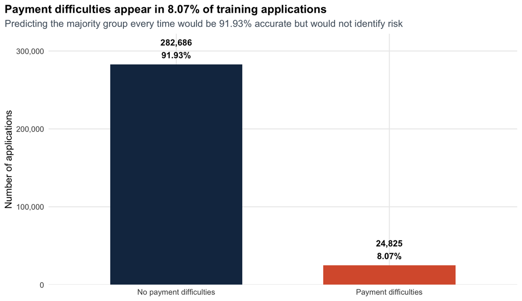

```r
# Count both target groups and create readable labels.
target_summary <- train[, .(Applications = .N), by = TARGET]
target_summary[, Share := Applications / sum(Applications)]
target_summary[, Outcome := fifelse(TARGET == 1,
                                    "Payment difficulties", "No payment difficulties")]

ggplot(target_summary, aes(x = Outcome, y = Applications, fill = factor(TARGET))) +
  geom_col(width = 0.62, show.legend = FALSE) +
  geom_text(aes(label = paste0(fmt_n(Applications), "\n", pct(Share, 0.01))),
            vjust = -0.35, fontface = "bold", size = 3.8) +
  scale_fill_manual(values = c(navy, coral)) +
  scale_y_continuous(labels = label_comma(), expand = expansion(mult = c(0, 0.14))) +
  labs(
    title = "Payment difficulties appear in 8.07% of training applications",
    subtitle = "Predicting the majority group every time would be 91.93% accurate but would not identify risk",
    x = NULL, y = "Number of applications"
  )
```

There are about 11.4 applicants without payment difficulties for every applicant with payment difficulties. Because of this imbalance, a model could have high accuracy by predicting the majority class almost every time. ROC AUC will help measure how well the model ranks applicants, and precision-recall results will show how well it identifies the smaller difficult-payment group. I will also need calibration and threshold tables that show how many applicants would be approved or flagged at different score cutoffs. Cross-validation should keep a similar target percentage in each fold, and any resampling or class weights must be applied inside the training folds.

## Missing values

### Extent and concentration

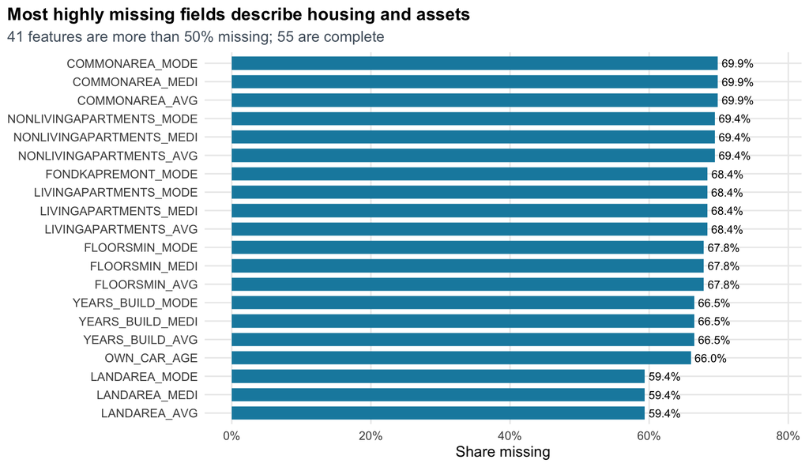

```r
# Calculate the missing rate for every column and show the 20 highest rates.
missing_profile <- data.table(
  Feature = names(train),
  Missing = vapply(train, function(x) sum(is.na(x)), integer(1)),
  Missing_rate = vapply(train, function(x) mean(is.na(x)), numeric(1))
)
missing_profile <- missing_profile[order(-Missing_rate)]

top_missing <- missing_profile[1:20]
ggplot(top_missing, aes(x = reorder(Feature, Missing_rate), y = Missing_rate)) +
  geom_col(fill = teal, width = 0.72) +
  geom_text(aes(label = pct(Missing_rate)), hjust = -0.12, size = 3.2) +
  coord_flip(clip = "off") +
  scale_y_continuous(labels = label_percent(), limits = c(0, 0.78)) +
  labs(
    title = "Most highly missing fields describe housing and assets",
    subtitle = paste0(sum(missing_profile$Missing_rate > 0.50),
                      " features are more than 50% missing; ",
                      sum(missing_profile$Missing_rate == 0), " are complete"),
    x = NULL, y = "Share missing"
  )
```

Most of the highly missing fields describe housing, including common areas, apartment space, floors, and building age. These fields are missing in similar patterns, which could mean the information did not apply or was not available for that applicant. For example, `OWN_CAR_AGE` is normally missing when the applicant does not own a car. Removing every column above one missing-value cutoff could remove information about why the value is missing.

The three external scores also have very different coverage. `EXT_SOURCE_1` is 56.38% missing, `EXT_SOURCE_3` is 19.83% missing, and `EXT_SOURCE_2` is only 0.21% missing. Because these scores have a strong relationship with the target later in the analysis, I will need to compare different ways of handling their missing values.

### Missing values and the target

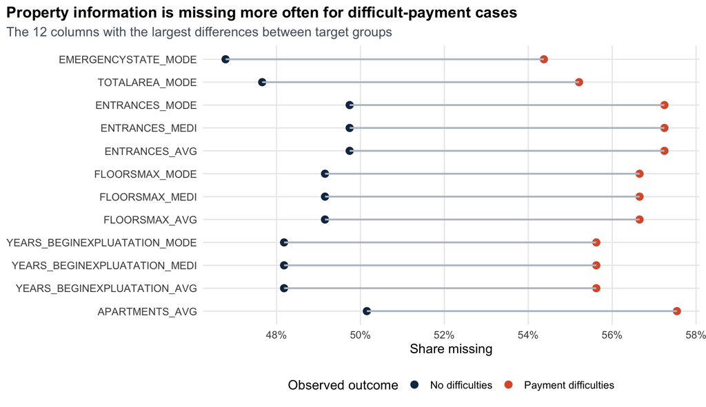

```r
# Compare missing rates for the two target groups and rank the largest differences.
missing_by_target <- rbindlist(lapply(names(train), function(v) {
  data.table(
    Feature = v,
    `No difficulties` = mean(is.na(train[TARGET == 0][[v]])),
    `Payment difficulties` = mean(is.na(train[TARGET == 1][[v]]))
  )
}))
missing_by_target[, Gap := `Payment difficulties` - `No difficulties`]
missing_gap <- missing_by_target[order(-abs(Gap))][1:12]

missing_gap_long <- melt(
  missing_gap,
  id.vars = c("Feature", "Gap"),
  measure.vars = c("No difficulties", "Payment difficulties"),
  variable.name = "Outcome", value.name = "Missing_rate"
)

ggplot(missing_gap_long,
       aes(x = reorder(Feature, abs(Gap)), y = Missing_rate, color = Outcome)) +
  geom_point(size = 2.8) +
  geom_line(aes(group = Feature), color = "#b8c2cc", linewidth = 0.8) +
  coord_flip() +
  scale_color_manual(values = c(navy, coral)) +
  scale_y_continuous(labels = label_percent()) +
  labs(
    title = "Property information is missing more often for difficult-payment cases",
    subtitle = "The 12 columns with the largest differences between target groups",
    x = NULL, y = "Share missing", color = "Observed outcome"
  )
```

For several property fields, the missing rate is about seven percentage points higher for applicants with payment difficulties. This does not mean that missing property information causes payment problems. The pattern could be connected to housing type, income, location, or the way the information was collected. I will test missing-value flags and compare them with models that can handle missing values directly. Any values used for imputation must be calculated inside cross-validation so that the validation data does not influence training.

## Invalid codes and unusual values

```r
# Count selected data problems that need a preparation rule.
quality_issues <- data.table(
  Check = c(
    "DAYS_EMPLOYED equals 365,243",
    "CODE_GENDER equals XNA",
    "NAME_FAMILY_STATUS equals Unknown",
    "CNT_FAM_MEMBERS is missing",
    "AMT_ANNUITY is missing",
    "AMT_GOODS_PRICE is missing",
    "AMT_INCOME_TOTAL exceeds 10 million",
    "OWN_CAR_AGE exceeds 60 years"
  ),
  Rows = c(
    sum(train$DAYS_EMPLOYED == 365243, na.rm = TRUE),
    sum(train$CODE_GENDER == "XNA", na.rm = TRUE),
    sum(train$NAME_FAMILY_STATUS == "Unknown", na.rm = TRUE),
    sum(is.na(train$CNT_FAM_MEMBERS)),
    sum(is.na(train$AMT_ANNUITY)),
    sum(is.na(train$AMT_GOODS_PRICE)),
    sum(train$AMT_INCOME_TOTAL > 1e7, na.rm = TRUE),
    sum(train$OWN_CAR_AGE > 60, na.rm = TRUE)
  )
)
quality_issues[, Share := Rows / nrow(train)]
kable(quality_issues, digits = 4, format.args = list(big.mark = ","),
      caption = "Selected invalid-code and unusual-value checks")
```

Selected invalid-code and unusual-value checks

| Check | Rows | Share |
| --- | --- | --- |
| DAYS_EMPLOYED equals 365,243 | 55,374 | 0.1801 |
| CODE_GENDER equals XNA | 4 | 0.0000 |
| NAME_FAMILY_STATUS equals Unknown | 2 | 0.0000 |
| CNT_FAM_MEMBERS is missing | 2 | 0.0000 |
| AMT_ANNUITY is missing | 12 | 0.0000 |
| AMT_GOODS_PRICE is missing | 278 | 0.0009 |
| AMT_INCOME_TOTAL exceeds 10 million | 3 | 0.0000 |
| OWN_CAR_AGE exceeds 60 years | 3,339 | 0.0109 |

The values in `DAYS_BIRTH`, `DAYS_REGISTRATION`, and `DAYS_ID_PUBLISH` follow the data dictionary and are recorded as zero or negative days before the application. `DAYS_EMPLOYED = 365243`, however, is equal to about 1,000 years and cannot be a real employment length. This code appears in 55,374 rows, or 18.01% of the training data. I will replace it with a missing value, create a flag showing where the code appeared, and then convert the valid employment values into years.

The four `XNA` gender values and two `Unknown` family-status values should remain unknown instead of being guessed. The very high incomes and old vehicle ages are questionable, but the data alone does not prove that they are errors. I would compare results with and without a training-based cap before removing any records. The checks also found no zero or negative income or credit values, no applicants with more children than family members, and no valid employment length greater than the applicant’s age.

```r
# Create easier-to-read analysis variables without changing the raw columns.
eda <- copy(train)
eda[, AGE_YEARS := -DAYS_BIRTH / 365.25]
eda[, EMPLOYED_SENTINEL := DAYS_EMPLOYED == 365243]
eda[, EMPLOYED_YEARS := fifelse(DAYS_EMPLOYED < 0, -DAYS_EMPLOYED / 365.25, NA_real_)]
eda[, CREDIT_INCOME_RATIO := AMT_CREDIT / AMT_INCOME_TOTAL]
eda[, ANNUITY_INCOME_RATIO := AMT_ANNUITY / AMT_INCOME_TOTAL]
eda[, CREDIT_GOODS_RATIO := AMT_CREDIT / AMT_GOODS_PRICE]
eda[, EXTERNAL_SCORE_COUNT := rowSums(!is.na(.SD)),
    .SDcols = c("EXT_SOURCE_1", "EXT_SOURCE_2", "EXT_SOURCE_3")]
```

## Applicant and loan relationships

### Age

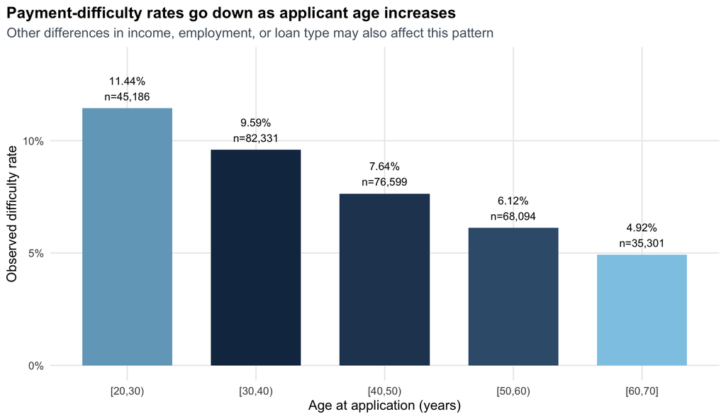

```r
# Group applicants into age bands and show the count and target rate.
age_summary <- eda[, .(
  Applications = .N,
  Difficulty_rate = mean(TARGET)
), by = .(Age_band = cut(
  AGE_YEARS, breaks = c(20, 30, 40, 50, 60, 70),
  right = FALSE, include.lowest = TRUE
))][order(Age_band)]

ggplot(age_summary, aes(x = Age_band, y = Difficulty_rate)) +
  geom_col(aes(fill = Applications), width = 0.7) +
  geom_text(aes(label = paste0(pct(Difficulty_rate, 0.01), "\nn=", fmt_n(Applications))),
            vjust = -0.35, size = 3.4) +
  scale_fill_gradient(low = "#8ecae6", high = navy, guide = "none") +
  scale_y_continuous(labels = label_percent(), limits = c(0, 0.135)) +
  labs(
    title = "Payment-difficulty rates go down as applicant age increases",
    subtitle = "Other differences in income, employment, or loan type may also affect this pattern",
    x = "Age at application (years)", y = "Observed difficulty rate",
    fill = "Applicants"
  )
```

The payment-difficulty rate goes down from 11.44% for applicants ages 20 through 29 to 4.92% for applicants ages 60 through 69. This pattern makes age a possible predictor, but it also creates fairness and policy concerns. The chart does not show that age causes payment difficulty. Before a model is used, its errors and approval results should be checked for each age group.

### External source scores

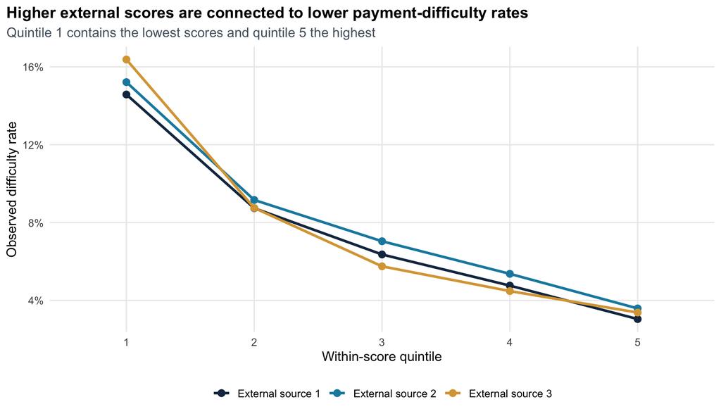

```r
# Split each external score into five equal-sized groups for comparison.
external_long <- rbindlist(lapply(
  c("EXT_SOURCE_1", "EXT_SOURCE_2", "EXT_SOURCE_3"),
  function(v) {
    x <- eda[!is.na(get(v)), .(Score = get(v), TARGET)]
    breaks <- unique(quantile(x$Score, probs = seq(0, 1, 0.2), na.rm = TRUE))
    x[, Quintile := cut(Score, breaks = breaks, include.lowest = TRUE, labels = FALSE)]
    x[, .(Applications = .N, Difficulty_rate = mean(TARGET)), by = Quintile][
      , Source := v]
  }
))

ggplot(external_long,
       aes(x = factor(Quintile), y = Difficulty_rate, color = Source, group = Source)) +
  geom_line(linewidth = 1.1) +
  geom_point(size = 2.6) +
  scale_color_manual(values = c(navy, teal, gold),
                     labels = c("External source 1", "External source 2", "External source 3")) +
  scale_y_continuous(labels = label_percent()) +
  labs(
    title = "Higher external scores are connected to lower payment-difficulty rates",
    subtitle = "Quintile 1 contains the lowest scores and quintile 5 the highest",
    x = "Within-score quintile", y = "Observed difficulty rate", color = NULL
  )
```

The external scores show the clearest single-variable relationship with payment difficulty. For `EXT_SOURCE_3`, the rate drops from about 16.38% in the lowest-score group to 3.38% in the highest-score group. `EXT_SOURCE_1` and `EXT_SOURCE_2` show the same general pattern. The dataset does not explain where these scores came from or how they were calculated, so Home Credit would need to confirm that they are stable, permitted, and explainable before using them. Since some of the scores are missing, the plotted applicants do not represent the full training population.

```r
# Check whether the number of available external scores relates to the target.
score_coverage <- eda[, .(
  Applications = .N,
  Difficulty_rate = mean(TARGET)
), by = EXTERNAL_SCORE_COUNT][order(EXTERNAL_SCORE_COUNT)]

kable(score_coverage, digits = 4, format.args = list(big.mark = ","),
      col.names = c("External scores available", "Applications", "Difficulty rate"),
      caption = "External score coverage and observed payment difficulty")
```

External score coverage and observed payment difficulty

| External scores available | Applications | Difficulty rate |
| --- | --- | --- |
| 0 | 172 | 0.0814 |
| 1 | 36,737 | 0.0992 |
| 2 | 161,013 | 0.0818 |
| 3 | 109,589 | 0.0730 |

Applicants with all three scores have a 7.30% payment-difficulty rate, compared with 9.92% for applicants with only one score. Only 172 applicants have no external scores, so their 8.14% rate is based on too few cases for a strong conclusion. The number of available scores may help prediction, but it may also show which applicants have more information available rather than their actual ability to repay.

### Housing and education

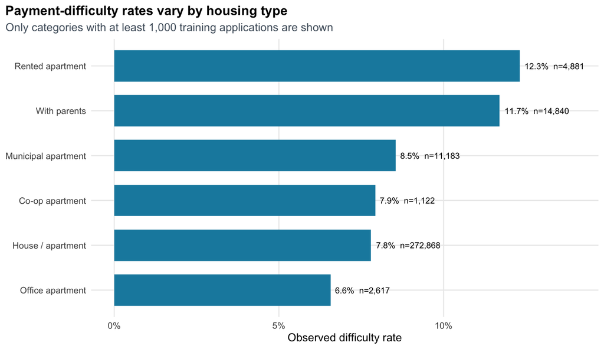

```r
# Compare categories with enough applications to give more stable rates.
category_rate <- function(variable, min_n = 1000) {
  eda[, .(Applications = .N, Difficulty_rate = mean(TARGET)), by = variable][
    Applications >= min_n][order(Difficulty_rate)]
}

housing <- category_rate("NAME_HOUSING_TYPE")
ggplot(housing, aes(x = reorder(NAME_HOUSING_TYPE, Difficulty_rate),
                    y = Difficulty_rate)) +
  geom_col(fill = teal, width = 0.7) +
  geom_text(aes(label = paste0(pct(Difficulty_rate, 0.1), "  n=", fmt_n(Applications))),
            hjust = -0.08, size = 3.2) +
  coord_flip(clip = "off") +
  scale_y_continuous(labels = label_percent(), limits = c(0, 0.14)) +
  labs(
    title = "Payment-difficulty rates vary by housing type",
    subtitle = "Only categories with at least 1,000 training applications are shown",
    x = NULL, y = "Observed difficulty rate"
  )
```

Applicants in rented apartments have a 12.31% payment-difficulty rate, and applicants living with parents have an 11.70% rate. The rate is 7.80% for applicants living in a house or apartment. Housing type could help prediction, but it is also connected to age, income, location, and loan type. A model would need to consider these variables together, and Home Credit would need to decide whether housing information is appropriate to use.

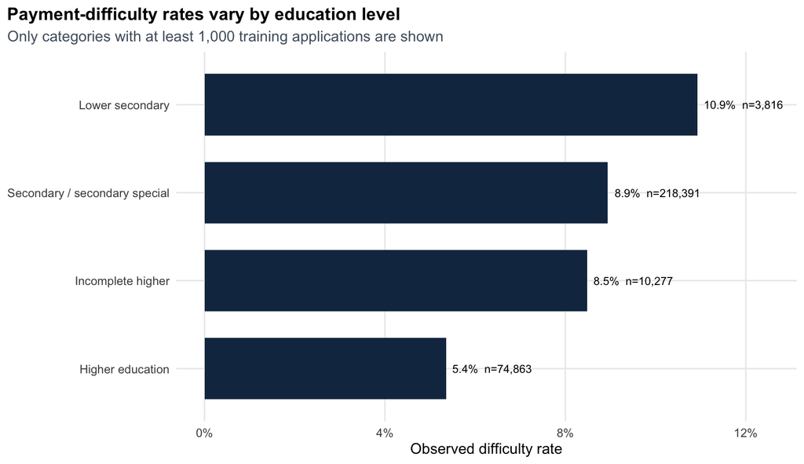

```r
# Show education groups with at least 1,000 applications and include their counts.
education <- category_rate("NAME_EDUCATION_TYPE")
ggplot(education, aes(x = reorder(NAME_EDUCATION_TYPE, Difficulty_rate),
                      y = Difficulty_rate)) +
  geom_col(fill = navy, width = 0.7) +
  geom_text(aes(label = paste0(pct(Difficulty_rate, 0.1), "  n=", fmt_n(Applications))),
            hjust = -0.08, size = 3.2) +
  coord_flip(clip = "off") +
  scale_y_continuous(labels = label_percent(), limits = c(0, 0.125)) +
  labs(
    title = "Payment-difficulty rates vary by education level",
    subtitle = "Only categories with at least 1,000 training applications are shown",
    x = NULL, y = "Observed difficulty rate"
  )
```

Among the larger education groups, the payment-difficulty rate ranges from 5.36% for higher education to 10.93% for lower secondary education. This is a relationship in the data and does not show that education causes the difference. Education may also represent other economic differences between applicants. I would compare model results with and without this type of information and check whether it creates unfair differences in decisions.

### Loan amounts and income ratios

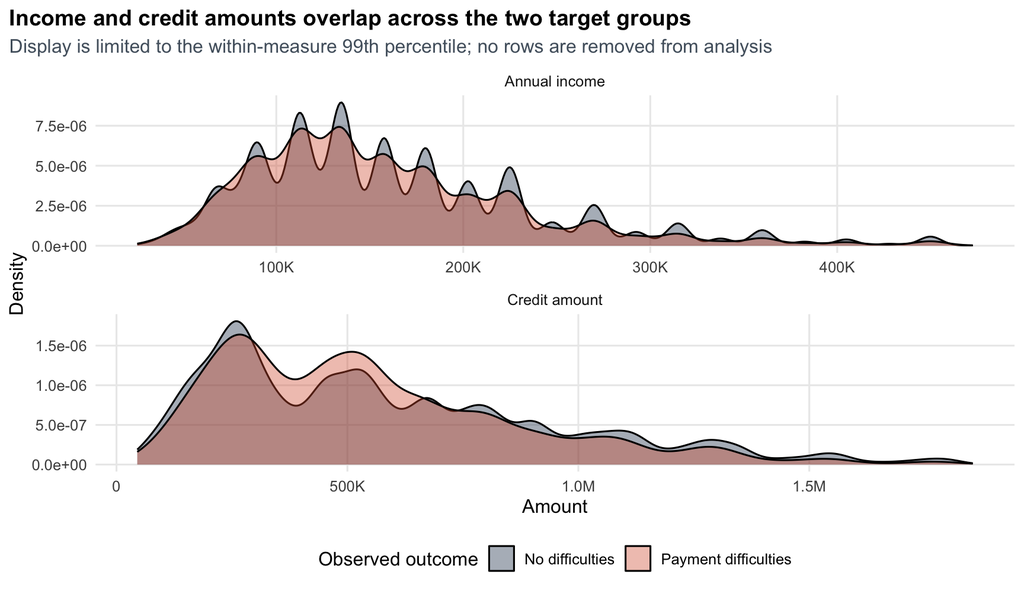

```r
# Limit the plot to the 99th percentile so a few extreme values do not hide the pattern.
amount_plot <- melt(
  eda[, .(
    TARGET,
    `Annual income` = AMT_INCOME_TOTAL,
    `Credit amount` = AMT_CREDIT
  )],
  id.vars = "TARGET", variable.name = "Measure", value.name = "Amount"
)
amount_plot <- amount_plot[
  , .SD[Amount <= quantile(Amount, 0.99, na.rm = TRUE)], by = Measure
]
amount_plot[, Outcome := fifelse(TARGET == 1, "Payment difficulties", "No difficulties")]

ggplot(amount_plot, aes(x = Amount, fill = Outcome)) +
  geom_density(alpha = 0.38, adjust = 1.2) +
  facet_wrap(~Measure, scales = "free", ncol = 1) +
  scale_fill_manual(values = c(navy, coral)) +
  scale_x_continuous(labels = label_number(scale_cut = cut_short_scale())) +
  labs(
    title = "Income and credit amounts overlap across the two target groups",
    subtitle = "Display is limited to the within-measure 99th percentile; no rows are removed from analysis",
    x = "Amount", y = "Density", fill = "Observed outcome"
  )
```

The income and credit distributions overlap across the two target groups. Income or loan amount by itself does not clearly separate applicants with and without payment difficulties. Ratios that compare the requested loan or annuity with income may be more useful than the original amounts, but a high income does not automatically mean low risk.

```r
# Summarize the new ratios and their simple correlations with TARGET.
ratio_summary <- data.table(
  Feature = c("Credit / income", "Annuity / income", "Credit / goods price"),
  Median = c(
    median(eda$CREDIT_INCOME_RATIO, na.rm = TRUE),
    median(eda$ANNUITY_INCOME_RATIO, na.rm = TRUE),
    median(eda$CREDIT_GOODS_RATIO, na.rm = TRUE)
  ),
  `99th percentile` = c(
    quantile(eda$CREDIT_INCOME_RATIO, 0.99, na.rm = TRUE),
    quantile(eda$ANNUITY_INCOME_RATIO, 0.99, na.rm = TRUE),
    quantile(eda$CREDIT_GOODS_RATIO, 0.99, na.rm = TRUE)
  ),
  `Correlation with TARGET` = c(
    cor(eda$CREDIT_INCOME_RATIO, eda$TARGET, use = "complete.obs"),
    cor(eda$ANNUITY_INCOME_RATIO, eda$TARGET, use = "complete.obs"),
    cor(eda$CREDIT_GOODS_RATIO, eda$TARGET, use = "complete.obs")
  )
)
kable(ratio_summary, digits = 3, caption = "Possible income and loan ratio features")
```

Possible income and loan ratio features

| Feature | Median | 99th percentile | Correlation with TARGET |
| --- | --- | --- | --- |
| Credit / income | 3.265 | 13.027 | -0.008 |
| Annuity / income | 0.163 | 0.483 | 0.014 |
| Credit / goods price | 1.119 | 1.475 | 0.069 |

These ratios could be used as new model features, but their simple linear correlations with `TARGET` are weak. The credit-to-goods-price ratio has the largest correlation of the three. A model may still find patterns that a simple correlation misses. Before using the ratios, I will need to handle missing denominators, check for division problems, and decide how to treat extreme values using only each training fold.

## Numeric relationships with the target

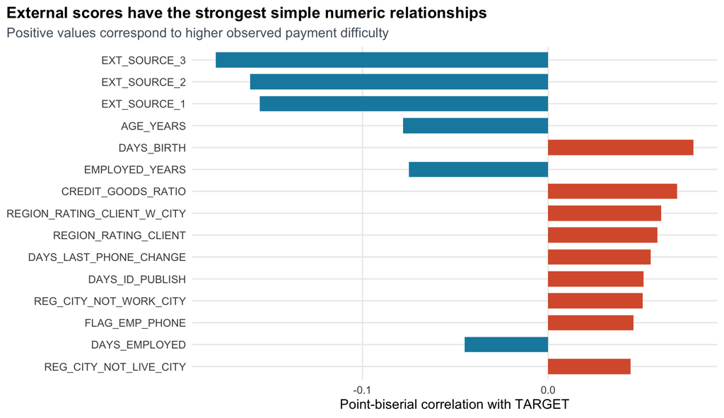

```r
# Rank numeric variables by the size of their correlation with TARGET.
# This is only a first check and is not the same as model feature importance.
numeric_features <- setdiff(
  names(eda)[vapply(eda, is.numeric, logical(1))],
  c("TARGET", "SK_ID_CURR")
)
target_correlations <- rbindlist(lapply(numeric_features, function(v) {
  data.table(
    Feature = v,
    Correlation = cor(eda[[v]], eda$TARGET, use = "pairwise.complete.obs")
  )
}))
top_correlations <- target_correlations[order(-abs(Correlation))][1:15]

ggplot(top_correlations,
       aes(x = reorder(Feature, abs(Correlation)), y = Correlation,
           fill = Correlation > 0)) +
  geom_col(width = 0.7, show.legend = FALSE) +
  coord_flip() +
  scale_fill_manual(values = c(teal, coral)) +
  labs(
    title = "External scores have the strongest simple numeric relationships",
    subtitle = "Positive values correspond to higher observed payment difficulty",
    x = NULL, y = "Point-biserial correlation with TARGET"
  )
```

The three external scores have the largest correlations with `TARGET`, with absolute values between about 0.16 and 0.18. Age, regional rating, the time since the last phone change, and the time since the identity document was issued have smaller relationships. The original `DAYS_EMPLOYED` column is affected by the impossible 365,243 value, so the model should use the cleaned employment length and the separate code flag instead. This correlation check is only a starting point because it does not find curved relationships, combinations of variables, or information in categorical columns.

## Training and test data comparison

The test file is not a labeled random sample that can be used for local model evaluation. It is a separate group of applications that the final model will score. Because of this, differences between the two files matter even when they contain the same predictor columns.

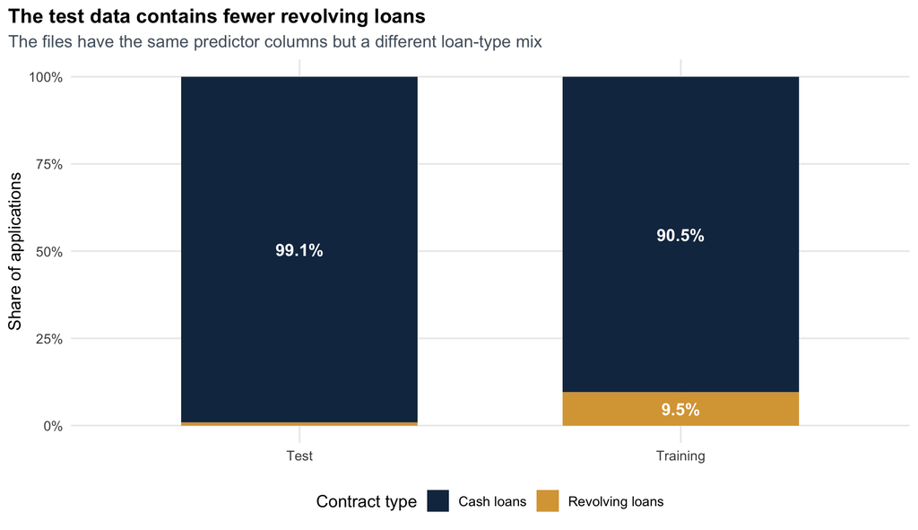

```r
# Compare the loan-type mix in the training and test files.
contract_mix <- rbindlist(list(
  train[, .(Applications = .N), by = NAME_CONTRACT_TYPE][, Dataset := "Training"],
  test[,  .(Applications = .N), by = NAME_CONTRACT_TYPE][, Dataset := "Test"]
))
contract_mix[, Share := Applications / sum(Applications), by = Dataset]

ggplot(contract_mix, aes(x = Dataset, y = Share, fill = NAME_CONTRACT_TYPE)) +
  geom_col(width = 0.62) +
  geom_text(aes(label = fifelse(Share < 0.02, "", pct(Share, 0.1))),
            position = position_stack(vjust = 0.5), color = "white", fontface = "bold") +
  scale_fill_manual(values = c(navy, gold)) +
  scale_y_continuous(labels = label_percent()) +
  labs(
    title = "The test data contains fewer revolving loans",
    subtitle = "The files have the same predictor columns but a different loan-type mix",
    x = NULL, y = "Share of applications", fill = "Contract type"
  )
```

Revolving loans make up 9.52% of the training applications but only 0.90% of the test applications. The median credit amount is also lower in the test data, at 450,000 compared with 513,531 in training. Median income is higher in the test data, at 157,500 compared with 147,150. These differences could affect the model’s predicted probabilities and the importance of loan-product variables.

```r
# Summarize selected differences between the training and test files.
cohort_summary <- data.table(
  Measure = c(
    "Revolving loan share",
    "Median credit amount",
    "Median annual income",
    "EXT_SOURCE_1 missing",
    "EXT_SOURCE_3 missing"
  ),
  Training = c(
    mean(train$NAME_CONTRACT_TYPE == "Revolving loans"),
    median(train$AMT_CREDIT, na.rm = TRUE),
    median(train$AMT_INCOME_TOTAL, na.rm = TRUE),
    mean(is.na(train$EXT_SOURCE_1)),
    mean(is.na(train$EXT_SOURCE_3))
  ),
  Scoring = c(
    mean(test$NAME_CONTRACT_TYPE == "Revolving loans"),
    median(test$AMT_CREDIT, na.rm = TRUE),
    median(test$AMT_INCOME_TOTAL, na.rm = TRUE),
    mean(is.na(test$EXT_SOURCE_1)),
    mean(is.na(test$EXT_SOURCE_3))
  )
)

# Build character display columns so percentages and currency can coexist safely.
cohort_display <- cohort_summary[, .(
  Measure,
  Training = c(
    pct(Training[1], 0.01),
    fmt_n(Training[2:3]),
    pct(Training[4:5], 0.01)
  ),
  Scoring = c(
    pct(Scoring[1], 0.01),
    fmt_n(Scoring[2:3]),
    pct(Scoring[4:5], 0.01)
  )
)]
kable(cohort_display, caption = "Selected comparisons between training and test data")
```

Selected comparisons between training and test data

| Measure | Training | Scoring |
| --- | --- | --- |
| Revolving loan share | 9.52% | 0.90% |
| Median credit amount | 513,531 | 450,000 |
| Median annual income | 147,150 | 157,500 |
| EXT_SOURCE_1 missing | 56.38% | 42.12% |
| EXT_SOURCE_3 missing | 19.83% | 17.78% |

`EXT_SOURCE_1` has fewer missing values in the test data, with 42.12% missing compared with 56.38% in training. These differences do not prevent the project from moving forward, but they mean validation should be checked by contract type and the final model should be monitored for changes in its predictions. The training data also contains rare labels that are not in the test data, including `XNA`, `Unknown`, and `Maternity leave`. The encoding method will need to handle categories that are missing from one dataset or appear later in new data.

## Data preparation decisions

| Finding | Preparation decision | Validation safeguard |
| --- | --- | --- |
| One row per applicant and unique IDs | Keep `SK_ID_CURR` as an identifier and do not use it as a predictor | Check that IDs stay unique after every merge |
| `TARGET` is only in training | Separate the target before preparing predictors | Fit every preparation step on the training folds only |
| Only 8.07% of cases have `TARGET = 1` | Keep the target percentage similar across folds and test model weights if needed | Report ROC AUC, PR AUC, calibration, a confusion matrix, and approval-threshold results |
| Many related fields are missing | Compare models that handle missing values with training-fold imputation and selected missing-value flags | Check results for different missing-data groups and for the test population |
| `DAYS_EMPLOYED = 365243` is an impossible code | Replace it with missing, keep a separate flag, and convert valid values to years | Confirm that the cleaned employment field has no positive day values |
| Monetary values are skewed and contain extremes | Compare log or robust transformations with tree models; only cap values using training-fold cutoffs | Compare results with and without capped values |
| External scores are useful but incomplete | Keep the scores and a count of available scores if Home Credit can explain and use them | Compare models with and without the external scores |
| Loan type and score coverage differ between train and test | Check validation results by contract type and monitor future population changes | Report performance by contract type and recalibrate if necessary |
| Some fields may represent demographic or economic differences | Do not treat group differences as causes and check the model for unfair errors | Compare calibration and false-positive and false-negative rates by group |

These decisions give me a clear preparation plan that can be checked during modeling. They also prevent the full labeled dataset from influencing imputation, outlier cutoffs, or category encoding before cross-validation.

## Results and next steps

1. **The application files have one row per applicant.** Each `SK_ID_CURR` is unique. Any supplementary table with several records per applicant must be summarized before it is joined to the application data.
2. **The target is imbalanced.** There are 24,825 difficult-payment cases out of 307,511 training applications, which is 8.07%. Accuracy by itself will not show whether a model is useful.
3. **Missing values are an important part of the data.** Forty-one fields are more than 50% missing, especially the property fields. Missing rates also differ between the two target groups, so I will compare missing-value flags, imputation, and models that handle missing values directly.
4. **Some values need to be cleaned.** The 365,243 employment-day code is impossible and appears often. Rare invalid labels and extreme monetary values also need consistent rules.
5. **External scores and age have the clearest individual relationships with the target.** Payment-difficulty rates go down as the external scores increase and as age increases. Before using these variables, Home Credit would need to review whether they are explainable and whether they create unfair differences.
6. **Income and loan amount do not separate the target groups by themselves.** Their distributions overlap, and the three income and credit ratios have weak linear correlations with `TARGET`. Models that can find curved relationships and interactions may work better.
7. **The training and test applications are different.** The test file has fewer revolving loans, a lower median credit amount, a higher median income, and different external-score coverage. Validation and monitoring should check whether these differences change model performance.

For modeling, I would first build a regularized logistic regression as a simple baseline. I would then compare it with a tree-boosting model that can handle missing values and nonlinear relationships. I would choose the final approach based on cross-validation results, calibration, approval tradeoffs, results by contract type, and fairness checks instead of choosing it from one score alone.

## How I used AI

I used generative AI to help turn the business problem into possible EDA questions, write and revise R code, suggest data-quality checks, and organize the notebook. It helped me check the data grain, missing values, unusual codes, target imbalance, and differences between the training and test files. AI proposed the five EDA questions based on the business problem, assignment instructions, and data structure. I used those questions to organize the analysis.

AI made it faster to create a broad set of checks, but I still needed to verify the work. Every count, percentage, table, and plot in this notebook was produced by running the code on the supplied CSV files. I also checked column meanings against the provided data dictionary. I avoided conclusions that claimed a variable caused payment difficulty, and I did not automatically delete values just because they looked unusual. The main benefit of AI was speed. The main risk was that an explanation could sound confident even when the data did not provide enough context, so the analysis still required review before it could be used for modeling or loan decisions.